# Rebuilding a Nominations Dataset: 55 Contests from a Printed Book

The dataset that was never released, and a column that exists in none of its tables

Democracy’s Data

Last updated September 13, 2026 at 10:53a EDT

Six political scientists spent a decade studying how candidates get nominated for the House of Representatives. They did 346 interviews across 55 contests, and in 2026 they published what they found. They did not publish a data file. There is no download link, no repository, no spreadsheet. **The evidence is printed as twenty-three tables scattered across eleven chapters of a book.**

A book is often treated as the end of the evidence. Is it? Can a reader get the data back out, check it against itself, and learn something the authors never printed? This brief does exactly that, and the answer is yes three times over. The reassembly finds two mistakes in the book and one finding its authors never drew, because none of the three is visible until the tables sit side by side.

## The test

The source is *Parties on the Ground* (2026), by Kathleen Bawn, John Zaller and four colleagues, published by the University of Chicago Press and read here from the [printed book](https://doi.org/10.7208/chicago/9780226853314.001.0001).[^1] Its tables 5.2, 6.2, 6.3, 9.1 and 10.1 cover 55 House nominations from the 2013–14 cycle. The book’s subject is the **nomination**, the contest that decides whose name appears on the November ballot for each party. The authors studied the nominations that were both **open**, with no sitting member running, and **winnable**, meaning the winner had a real chance in November: the contests that send new people to Congress.

No other source holds this evidence. The roster chapter introduces this cluster’s records, the official lists of who ran and who held each seat. None of those records can say who *organized* behind a candidate, which is what 346 interviews can. The book announces an online appendix at https://osf.io/s5982, but that address returned a sign-in page when this was written, so the printed tables are the only public form of the data.

The test: transcribe the tables that share a key, join them, rebuild the one column the book totals but never itemizes, and check every derived count against a number the book itself prints.

## The data

Four of the twenty-three tables describe the same 55 contests and label each one the same way, with a code like `PA-13D` — Pennsylvania’s thirteenth district, Democratic side. Because they share that code, they can be joined.

| Table | What it gives you |
| --- | --- |
| Table 10.1 | Every nomination: who won, which group backed them, and why that group cared |
| Table 5.2 | The 32 contests where groups worked together behind one candidate |
| Tables 6.2 and 6.3 | How many winners each kind of backing produced – as totals only |
| Table 9.1 | For 33 Republicans: their faction, and business PAC money in dollars |

| Quantity | Value |
| --- | --- |
| Nominations studied | 55 |
| Republican | 35 |
| Democratic | 20 |
| Interviews | 346 |
| Tables in the book | 23 |
| Tables that share a key | 4 |

Read the third row of the first table again. **Tables 6.2 and 6.3 give totals and no rows.** They report that 28 winners were carried by coordinated groups, 9 by money, 6 by volunteers and 4 by professional campaign help. They never say which contest was which. That column is the one this brief needs, and it is in no table. It is rebuilt from sentences instead of cells, in four steps.

The first step is an annotation almost small enough to miss: table 5.2 marks three contests `(1st and 2nd)` or `(2nd)`, where the group’s candidate came second. Expanding those turns 32 contests into 34 candidates, of whom 30 won — which is what chapter 6 says in words. The second is a sentence that moves two names out of the coordination column into the money column, because the authors “judged the money to have had a bigger impact.” The third is a set of lists chapter 6 prints in ordinary paragraphs: the candidates backed mainly by money, by professional help, by volunteers. **Then whatever is left over is the answer**: 8 contests match none of those lists, and the totals table says 8 winners had no backing the authors could identify.

Two contests show the steps at work. PA-13D, Pennsylvania’s thirteenth on the Democratic side, is in table 5.2’s list of 32: groups coordinated there, its winner, Boyle, was their candidate, and chapter 6 does not move him, so his `anchor_form` is *coordination* and the row records where that came from. MI-12D, Michigan’s twelfth on the Democratic side, is not in table 5.2, is not one of the two winners chapter 6 reassigns, and appears in none of its prose lists of money-, professional- or volunteer-backed winners; table 10.1 names its winner, Dingell, and gives her backing only as “Self and broad party support.” Nothing places her anywhere, so she is one of the 8 left over — which is what the totals table, read the other way round, said there had to be.

| Step | Derived here | Printed in the book |
| --- | --- | --- |
| Expand the (1st and 2nd) annotations | 30 | 30 (chapter 6) |
| Move the two winners chapter 6 reassigns | 28 | 28 (table 6.3) |
| Take the lists chapter 6 prints in prose | 19 | 9 + 6 + 4 (table 6.3) |
| Whatever is left | 8 | 8 (table 6.2) |

**Four counts, arrived at four different ways, land on four numbers the book already printed.** None was adjusted to fit, and the table is not kept unless all four agree. It is still a derived column, and every row says so in `anchor_form_source` — the 8 leftovers carry the note *left over: stated in no table and no sentence*.

The join is also where the checking happens, because joining puts two claims about the same contest next to each other, where they can contradict. **Two district codes in the book are wrong, and both were found this way.**

| Race | Candidate | What the book prints |
| --- | --- | --- |
| FL-13R | Jolly | table 9.1c prints FL-19 for Jolly; Jolly won FL-13 |
| MI-14D | Lawrence | table 10.1 prints MI-4D; Lawrence won MI-14D |

Neither mistake is visible in the table it appears in; a district code looks fine on its own. The check that caught them is one line: every race code in a smaller table must match a row in the big one. Two did not. The join also found two tables disagreeing about 3 contests:

| Race | Candidate | Table 10.1 says the backer was | Tables 6.2/6.3 say the backing was |
| --- | --- | --- | --- |
| CA-45R | Walters | Finance/self-anchored | none or unclassified |
| TX-36R | Babin | Dentists/self-anchored | none or unclassified |
| WI-6R | Grothman | Tea Party and GOP activists | none or unclassified |

One table names a backer; the other counts the same candidate among those with none. The explanation is a threshold: to count, a group had to supply at least $250,000, or $400,000 in races with a runoff (a second round of voting, required in some states when nobody wins a majority in the primary), and these candidates had a clear group behind them that gave less. **The disagreement is not an error. It is a cutoff becoming visible**, and both readings are kept side by side rather than one being picked.

The finished table, `nominations.csv`, holds 55 rows and nineteen columns. Among them, by name: the race code and winner, the backer (`anchor`), why that group cared (`motive`), what the backing consisted of (`anchor_form`, the rebuilt column), the `faction` for Republicans, and `business_pac_usd` from table 9.1 — money from business political action committees, the committees through which companies and trade associations give to campaigns.

> **Before you read on, write a number down.** The book divides Republican winners into establishment candidates and **insurgents**, who ran against the party leadership. Of the 12 insurgents who won a nomination, **how many won a contest where groups had coordinated behind somebody** — any coordination at all, for any candidate, including against them? Commit to a count out of 12 before you look at the figures.

## What it says about democracy

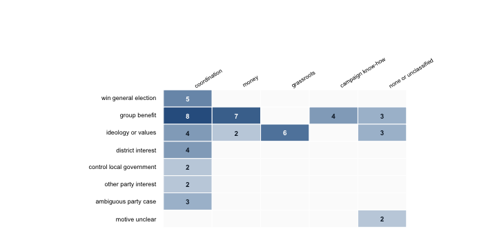

**Figure 1. Why each group got involved, against what it actually supplied.** A grid rather than a bar chart, because the interesting cells are the empty ones and a bar chart would hide them behind totals. Rows are the reason the authors judged a group to have backed its candidate, columns the resource that backing consisted of, cells counts of nominations.

Most of the grid is empty, and the empty cells are the point. Every contest where the goal was simply winning in November was carried by coordinated groups, never by money or volunteers alone. Every volunteer-driven campaign sits in one row, the one for groups motivated by values rather than material interest. Read down the tallest column and you get the book’s headline: 28 of 55 winners were carried by groups that worked together, more than all other kinds of backing combined.

The comparison the authors never printed comes from crossing two chapters. They report how often coordination appeared in a district, and separately which camp each Republican winner belonged to. They never cross the two, because faction and coordination sit in different chapters.

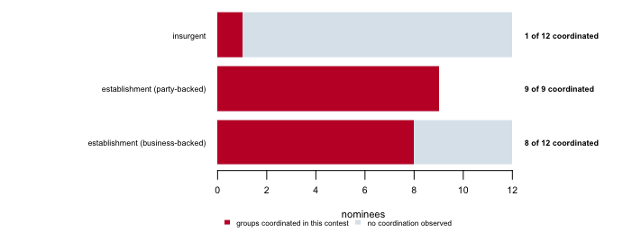

**Figure 2. Coordination behind each kind of Republican nominee.** Each bar is all the winners of that type; the dark part is those who won a contest where groups had coordinated behind some candidate.

Most readers guess four or five insurgents, because coordination sounds like something that happens in most competitive races. It is **1 of 12**. At the other end, every one of the **9 of 9** party-backed establishment nominees won a contest with coordination in it. Those two rows are the same fact seen from both ends: where groups organised behind a candidate, an insurgent almost never emerged as the winner, and where no group organised, insurgents won regularly.

The money runs the same way.

| What backed the winner | Republican nominees | Median business PAC money | Mean |
| --- | --- | --- | --- |
| coordination | 16 | $38,600 | $65,557 |
| money | 6 | $49,204 | $85,852 |
| grassroots | 6 | $5,750 | $14,000 |

A Republican carried by volunteers took a median of **$5,750** from business PACs. A Republican carried by coordinated groups took **$38,600**. The book argues that volunteer campaigns are a real alternative to money; here that argument is a number.

## What this brief cannot tell you

**It cannot tell you that coordination defeats insurgents.** Figure 2 shows two things happening in the same contests. It cannot show which caused which, and the authors say so directly: groups may organise behind candidates who were going to win anyway. Worse, the two columns were not decided independently — the same researchers judged both, from the same interviews, and write that they “acknowledge the potential for bias in this situation.”

**Every classification here is somebody’s judgment.** Insurgent or establishment, backed or not backed, and the reason a group cared are readings of 346 interviews by the six people who did them. The dollar amounts and vote counts are facts; the labels are not. The thresholds are arbitrary too, and the authors call them that: one candidate missed the $250,000 line by $20,000 and is filed among those with no backer. Move the line and Figure 1 changes shape.

**3 of the 55 rows carry two answers**, because two tables in one book disagree, and nothing here resolves that.

**And these are open seats only**: 55 contests with no sitting member, in one election cycle, in districts one party was expected to win. Nothing here describes a race against an incumbent, which is most races.

## What you should have learned

- A book is a data format — a bad one, but a recoverable one: 55 rows and nineteen columns came out of its printed tables, and not one came from a file.
- The join is the check: matching race codes across tables surfaced 2 wrong district codes and a 3-contest disagreement that no single table shows.
- A column the book only totals can be rebuilt from prose, provided every derived count lands on a number the book prints — here, four counts by four routes.
- Coordinated groups carried 28 of the 55 winners, more than every other kind of backing combined, and only 1 of 12 insurgent won a contest where groups had coordinated.
- The 3-contest disagreement between tables is not an error but a visible cutoff: a backer under the authors’ $250,000 threshold counts in one chapter and not in another.

## Extensions

None of these is answered above, and every one can be answered from the tables the Sources section hands over.

- `nominations.csv` has an `anchor_form` for each contest and an `anchor_form_source` saying where it came from. Count how many were recovered from prose rather than a table. How much of this dataset had to be rebuilt by hand?
- `by_faction.csv` reports `pct_coordinated` by faction. Which faction is most coordinated, and does that match how those candidates describe themselves?
- `pac_by_anchor.csv` gives `median_pac` and `mean_pac` by anchor form, and the two are far apart. Which would you report, and what is the gap telling you?
- `by_anchor.csv` crosses motive against the form of support. Find the combinations with no cases at all. Is that a fact about politics, or about how the categories were drawn?

Two stretch ideas point past the spreadsheet. The same 2014 cycle appears in two sibling briefs: `primary-defeats` counts incumbents losing primaries, and `primary-positions` reads what that cycle’s candidates would say on their own websites. Pick one of the 55 contests and follow its winner through both. And check whether the announced appendix at https://osf.io/s5982 has become readable; if it has, compare its file against the table rebuilt here.

## Sources

**Data**

- Bawn, K., Brown, K., Ocampo, A. X., Patterson, S. Jr., Ray, J. L. and Zaller, J. (2026). *Parties on the Ground: A Study of Nominations for the House of Representatives.* University of Chicago Press. https://doi.org/10.7208/chicago/9780226853314.001.0001; publisher’s page https://press.uchicago.edu/ucp/books/book/chicago/P/bo274765537.html — tables 5.2, 6.2, 6.3, 9.1 and 10.1, covering 55 winnable open-seat House nominations in the 2013–14 cycle. **Every figure, classification and dollar amount above is theirs**, transcribed from the printed pages and cited to the table it came from. The authors state that the study is exploratory and that none of its conclusions has been tested as a hypothesis. The five transcribed tables are kept beside this brief exactly as read off the page, the derived column is checked against the four printed totals, and the validation results are reproduced in `checks.csv`.

Facts are not owned, and these are facts: race codes, names, dollar amounts, counts. The judgments attached to them are the authors’ scholarly work, are used here to describe and check their own book, and are attributed throughout.

**Academic literature**

- Hall, A. B. (2019). *Who Wants to Run? How the Devaluing of Political Office Drives Polarization.* University of Chicago Press. https://press.uchicago.edu/ucp/books/book/chicago/W/bo35612049.html
- Boatright, R. G. (2014). *Congressional Primary Elections.* Routledge. https://www.routledge.com/Congressional-Primary-Elections/Boatright/p/book/9780415642828
- Ocampo, A. X. (2018). “The Politics of Inclusion: A Sense of Belonging to U.S. Society and Latino Political Participation.” Cited by the authors for the finding that who is vetted decides what representation a district gets.

**The data itself**

Every figure above is drawn from these tables. They are plain CSV, they open in a spreadsheet, and they are yours to take further.

`by_anchor.csv`, `by_faction.csv`, `nominations.csv`, `pac_by_anchor.csv`

One more file is not data about the subject – it is how this chapter checked its own work: `checks.csv`, the arithmetic verified before anything was drawn.

[^1]: Kathleen Bawn, Knox Brown, Angela X. Ocampo, Shawn Patterson Jr., John L. Ray and John Zaller, *Parties on the Ground: A Study of Nominations for the House of Representatives* (Chicago: University of Chicago Press, 2026), https://doi.org/10.7208/chicago/9780226853314.001.0001; the publisher’s page is https://press.uchicago.edu/ucp/books/book/chicago/P/bo274765537.html.